# Designing Experiments

Fri Nov 4, 2016

## Recall

- Say its the early 1900's, and you are a statistician and you meet someone who claims to be able to tell by tasting whether the tea or the milk was added first to a cup.
- You call BS and think they are just guessing.
- Say you have 8 cups, tea, and milk handy. How would you **design an experiment** to test whether a) they can really tell which came first or b) they are just guessing?
- Brainstorm all the components of this experiment with your seatmates. To revisit later: Then think about how you can implement this with `resampl()`ing.

Let's pick some pods at random…

## Randomness

We'll view randomness in this course largely through two lenses:

See blackboard notes.

## Explanatory and Response Variables

A medical doctor pours over some his patients' medical records and observes:

People who do this:

Wake up with this:

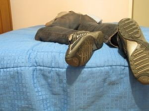

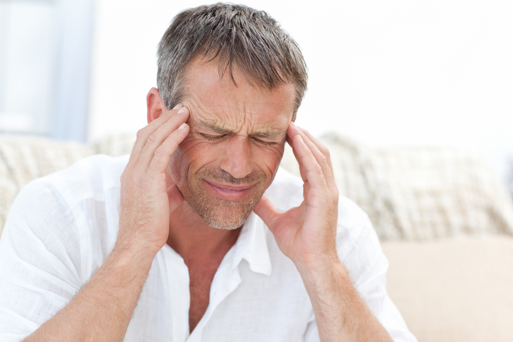

## Explanatory and Response Variables

He then asserts the following **causal** relationship:

- **Explanatory AKA treatment variable**: sleeping with shoes on
- **Response variable**: causes one to wake up with a headache

What's wrong?

## Diagram:

See blackboard notes.

## Mantra of Statistics

**Correlation is not necessarily causation**:

- [Spurious correlations](http://tylervigen.com/spurious-correlations)
- [Organic food causes autism!](http://io9.gizmodo.com/on-correlation-causation-and-the-real-cause-of-auti-1494972271)
- Does college cause higher earnings? See blackboard diagram.

## Two Types of Studies

See blackboard notes.

## Asserting Causality

- Making causal statements with observational studies is harder because you need to **control for** (account for) all possible confounding variables; in this case alcohol.
- But you may not have access to all confounding variables.
- Prof. Caitlin Myers' "ECON 212 Empirical Economic Research" this Spring will study methods that attempt to make **causal statements** despite only having observational data.

## Principles of Designing Experiements

See blackboard notes.

## Today's Learning Checks

I went to grad school in Seattle, where Garfield High School is located. Famous alums include:

- Quincy Jones: Producer and composer
- Jimi Hendrix: Guitarist
- Brandon Roy: Former NBA Rookie of the Year
- Macklemore: Rapper
- Minoru Yamasaki: World Trade Center architect

## Today's Learning Checks

Next door is Ezell's Fried Chicken. Oprah Winfrey apparently has it flown into to Chicago.

[figure not shown]

## Today's Learning Checks

One day I was raving about Ezell's Chicken. My friend Nick accused me "buying into the hype".

So what did we do?

## Today's Learning Checks

Fried Chicken Face Off:

Do people prefer this?

Or this?

[figure not shown]

[figure not shown]

## Today's Learning Checks

Say you have 12 grad students eager to procrastinate, how would you design a taste test to ascertain, independent of hype, which fried chicken tastes better?

Use the relevant principles of designing experiements from above.